# ADS 503 Team 4: Predicting Article Shares

# Load Data

```r
df <- read.csv("Datasets/OnlineNewsPopularity.csv")
dim(df)
```

```
[1] 39644    61
```

```r
summary(df)
```

```
     url              timedelta     n_tokens_title n_tokens_content n_unique_tokens    n_non_stop_words    n_non_stop_unique_tokens   num_hrefs      num_self_hrefs       num_imgs
 Length:39644       Min.   :  8.0   Min.   : 2.0   Min.   :   0.0   Min.   :  0.0000   Min.   :   0.0000   Min.   :  0.0000         Min.   :  0.00   Min.   :  0.000   Min.   :  0.000
 Class :character   1st Qu.:164.0   1st Qu.: 9.0   1st Qu.: 246.0   1st Qu.:  0.4709   1st Qu.:   1.0000   1st Qu.:  0.6257         1st Qu.:  4.00   1st Qu.:  1.000   1st Qu.:  1.000
 Mode  :character   Median :339.0   Median :10.0   Median : 409.0   Median :  0.5392   Median :   1.0000   Median :  0.6905         Median :  8.00   Median :  3.000   Median :  1.000
                    Mean   :354.5   Mean   :10.4   Mean   : 546.5   Mean   :  0.5482   Mean   :   0.9965   Mean   :  0.6892         Mean   : 10.88   Mean   :  3.294   Mean   :  4.544
                    3rd Qu.:542.0   3rd Qu.:12.0   3rd Qu.: 716.0   3rd Qu.:  0.6087   3rd Qu.:   1.0000   3rd Qu.:  0.7546         3rd Qu.: 14.00   3rd Qu.:  4.000   3rd Qu.:  4.000
                    Max.   :731.0   Max.   :23.0   Max.   :8474.0   Max.   :701.0000   Max.   :1042.0000   Max.   :650.0000         Max.   :304.00   Max.   :116.000   Max.   :128.000
   num_videos    average_token_length  num_keywords    data_channel_is_lifestyle data_channel_is_entertainment data_channel_is_bus data_channel_is_socmed data_channel_is_tech data_channel_is_world
 Min.   : 0.00   Min.   :0.000        Min.   : 1.000   Min.   :0.00000           Min.   :0.000                 Min.   :0.0000      Min.   :0.0000         Min.   :0.0000       Min.   :0.0000
 1st Qu.: 0.00   1st Qu.:4.478        1st Qu.: 6.000   1st Qu.:0.00000           1st Qu.:0.000                 1st Qu.:0.0000      1st Qu.:0.0000         1st Qu.:0.0000       1st Qu.:0.0000
 Median : 0.00   Median :4.664        Median : 7.000   Median :0.00000           Median :0.000                 Median :0.0000      Median :0.0000         Median :0.0000       Median :0.0000
 Mean   : 1.25   Mean   :4.548        Mean   : 7.224   Mean   :0.05295           Mean   :0.178                 Mean   :0.1579      Mean   :0.0586         Mean   :0.1853       Mean   :0.2126
 3rd Qu.: 1.00   3rd Qu.:4.855        3rd Qu.: 9.000   3rd Qu.:0.00000           3rd Qu.:0.000                 3rd Qu.:0.0000      3rd Qu.:0.0000         3rd Qu.:0.0000       3rd Qu.:0.0000
 Max.   :91.00   Max.   :8.042        Max.   :10.000   Max.   :1.00000           Max.   :1.000                 Max.   :1.0000      Max.   :1.0000         Max.   :1.0000       Max.   :1.0000
   kw_min_min       kw_max_min       kw_avg_min        kw_min_max       kw_max_max       kw_avg_max       kw_min_avg     kw_max_avg       kw_avg_avg    self_reference_min_shares
 Min.   : -1.00   Min.   :     0   Min.   :   -1.0   Min.   :     0   Min.   :     0   Min.   :     0   Min.   :  -1   Min.   :     0   Min.   :    0   Min.   :     0
 1st Qu.: -1.00   1st Qu.:   445   1st Qu.:  141.8   1st Qu.:     0   1st Qu.:843300   1st Qu.:172847   1st Qu.:   0   1st Qu.:  3562   1st Qu.: 2382   1st Qu.:   639
 Median : -1.00   Median :   660   Median :  235.5   Median :  1400   Median :843300   Median :244572   Median :1024   Median :  4356   Median : 2870   Median :  1200
 Mean   : 26.11   Mean   :  1154   Mean   :  312.4   Mean   : 13612   Mean   :752324   Mean   :259282   Mean   :1117   Mean   :  5657   Mean   : 3136   Mean   :  3999
 3rd Qu.:  4.00   3rd Qu.:  1000   3rd Qu.:  357.0   3rd Qu.:  7900   3rd Qu.:843300   3rd Qu.:330980   3rd Qu.:2057   3rd Qu.:  6020   3rd Qu.: 3600   3rd Qu.:  2600
 Max.   :377.00   Max.   :298400   Max.   :42827.9   Max.   :843300   Max.   :843300   Max.   :843300   Max.   :3613   Max.   :298400   Max.   :43568   Max.   :843300
 self_reference_max_shares self_reference_avg_sharess weekday_is_monday weekday_is_tuesday weekday_is_wednesday weekday_is_thursday weekday_is_friday weekday_is_saturday weekday_is_sunday
 Min.   :     0            Min.   :     0.0           Min.   :0.000     Min.   :0.0000     Min.   :0.0000       Min.   :0.0000      Min.   :0.0000    Min.   :0.00000     Min.   :0.00000
 1st Qu.:  1100            1st Qu.:   981.2           1st Qu.:0.000     1st Qu.:0.0000     1st Qu.:0.0000       1st Qu.:0.0000      1st Qu.:0.0000    1st Qu.:0.00000     1st Qu.:0.00000
 Median :  2800            Median :  2200.0           Median :0.000     Median :0.0000     Median :0.0000       Median :0.0000      Median :0.0000    Median :0.00000     Median :0.00000
 Mean   : 10329            Mean   :  6401.7           Mean   :0.168     Mean   :0.1864     Mean   :0.1875       Mean   :0.1833      Mean   :0.1438    Mean   :0.06188     Mean   :0.06904
 3rd Qu.:  8000            3rd Qu.:  5200.0           3rd Qu.:0.000     3rd Qu.:0.0000     3rd Qu.:0.0000       3rd Qu.:0.0000      3rd Qu.:0.0000    3rd Qu.:0.00000     3rd Qu.:0.00000
 Max.   :843300            Max.   :843300.0           Max.   :1.000     Max.   :1.0000     Max.   :1.0000       Max.   :1.0000      Max.   :1.0000    Max.   :1.00000     Max.   :1.00000
   is_weekend         LDA_00            LDA_01            LDA_02            LDA_03            LDA_04        global_subjectivity global_sentiment_polarity global_rate_positive_words
 Min.   :0.0000   Min.   :0.00000   Min.   :0.00000   Min.   :0.00000   Min.   :0.00000   Min.   :0.00000   Min.   :0.0000      Min.   :-0.39375          Min.   :0.00000
 1st Qu.:0.0000   1st Qu.:0.02505   1st Qu.:0.02501   1st Qu.:0.02857   1st Qu.:0.02857   1st Qu.:0.02857   1st Qu.:0.3962      1st Qu.: 0.05776          1st Qu.:0.02838
 Median :0.0000   Median :0.03339   Median :0.03334   Median :0.04000   Median :0.04000   Median :0.04073   Median :0.4535      Median : 0.11912          Median :0.03902
```

[output cut: 17 more lines]

The dataset has 39,644 samples and 61 variables.

# Missing Data

```r
sum(is.na(df))
```

```
[1] 0
```

None of the variables is missing any data so there is no need for imputation.

# Define Target and Predictors

```r
df <- df[, names(df) != "url"] # drop the url column, which functions as a sample ID
y <- df$shares # shares is the target variable
X <- df[, names(df) != "shares"]
```

# Target Distribution

```r
summary(y)
```

```
   Min. 1st Qu.  Median    Mean 3rd Qu.    Max.
      1     946    1400    3395    2800  843300
```

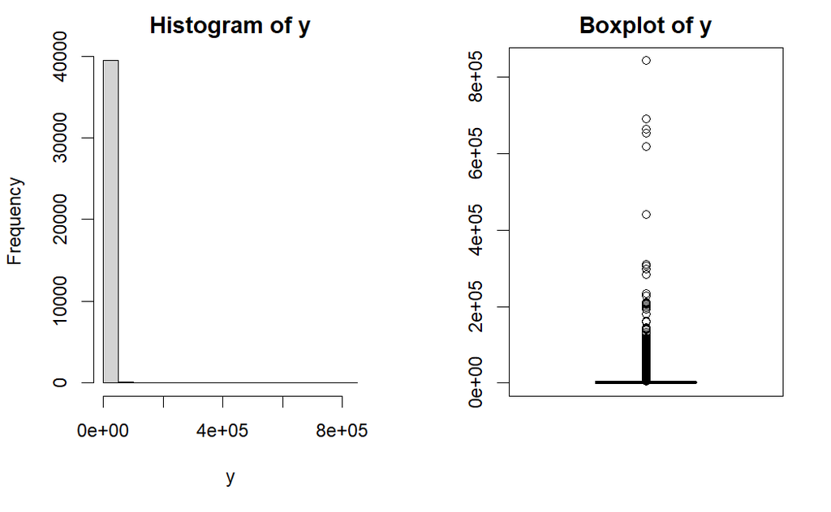

```r
par(mfrow = c(1, 2))
hist(y)
boxplot(y, main = "Boxplot of y")
```

The target distribution is highly right-skewed. Let’s try log transforming it.

```r
summary(log(y))
```

```
   Min. 1st Qu.  Median    Mean 3rd Qu.    Max.
  0.000   6.852   7.244   7.475   7.937  13.645
```

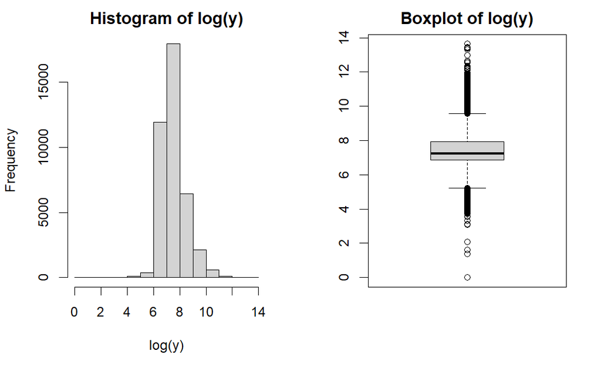

```r
par(mfrow = c(1, 2))
hist(log(y))
boxplot(log(y), main = "Boxplot of log(y)")
```

The log of the target is much less skewed. Let’s use the log-transformed version.

```r
y <- log(y)
```

## Target-Predictor Correlations

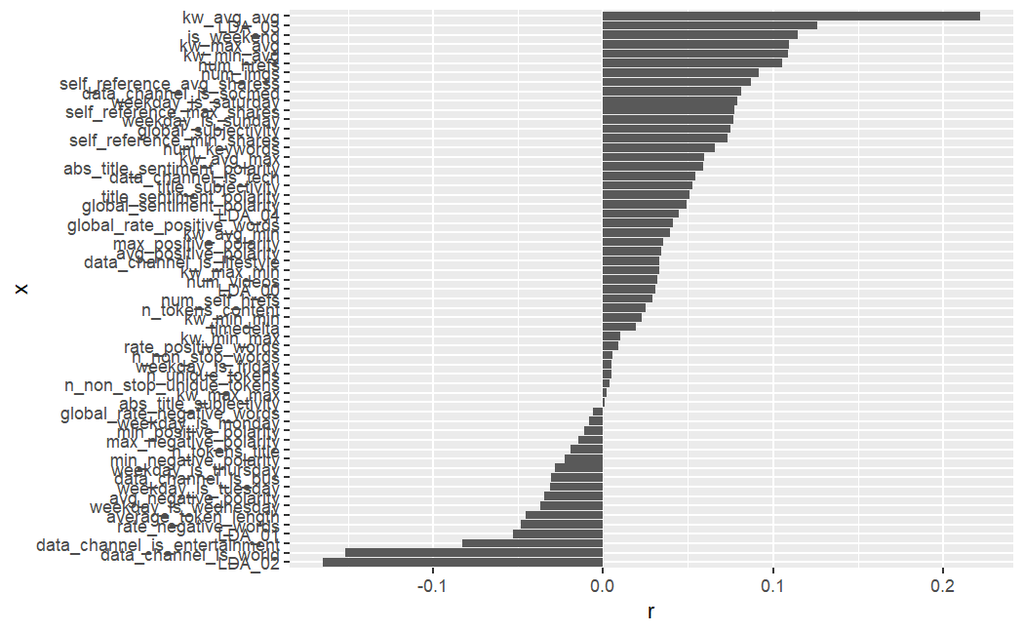

```r
library(tidyr)
library(dplyr)
library(ggplot2)
x <- names(X)
correlations <- data.frame(x)
correlations$r <- apply(correlations, 1, function(row) cor(X[, row["x"]], y)) # correlation between each predictor and the target
correlations <- correlations %>%
  dplyr::arrange(r) %>%
  dplyr::mutate(x = forcats::fct_inorder(x))
ggplot(correlations) +
  geom_col(aes(x = x, y = r)) +
  coord_flip()
```

```r
correlations
```

| x | r |
| --- | --- |
| LDA_02 | -0.1650336120 |
| data_channel_is_world | -0.1516506202 |
| data_channel_is_entertainment | -0.0825036542 |
| LDA_01 | -0.0529932702 |
| rate_negative_words | -0.0481707553 |
| average_token_length | -0.0452834316 |
| weekday_is_wednesday | -0.0365902248 |
| avg_negative_polarity | -0.0343099860 |
| weekday_is_tuesday | -0.0310734298 |
| data_channel_is_bus | -0.0305990105 |

[output cut: 49 more lines]

None of the target-predictor correlations is very strong. The strongest positive correlation is with kw_avg_avg, while the strongest negative correlation is with LDA_02.

```r
par(mfrow = c(1, 2))

plot(X[, "kw_avg_avg"], y, xlab = "kw_avg_avg")
lines(lowess(X[, "kw_avg_avg"], y), col = "red")
```

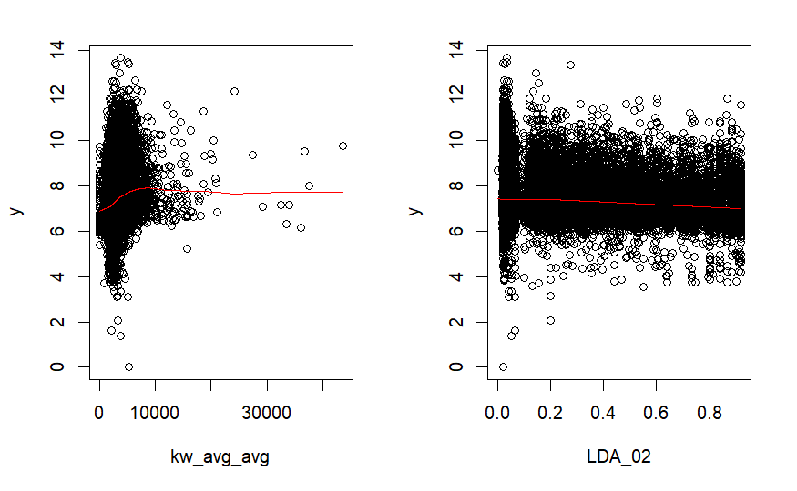

```r
plot(X[, "LDA_02"], y, xlab = "LDA_02")
lines(lowess(X[, "LDA_02"], y), col = "red")
```

# Predictor Distributions

## Near-Zero Variance

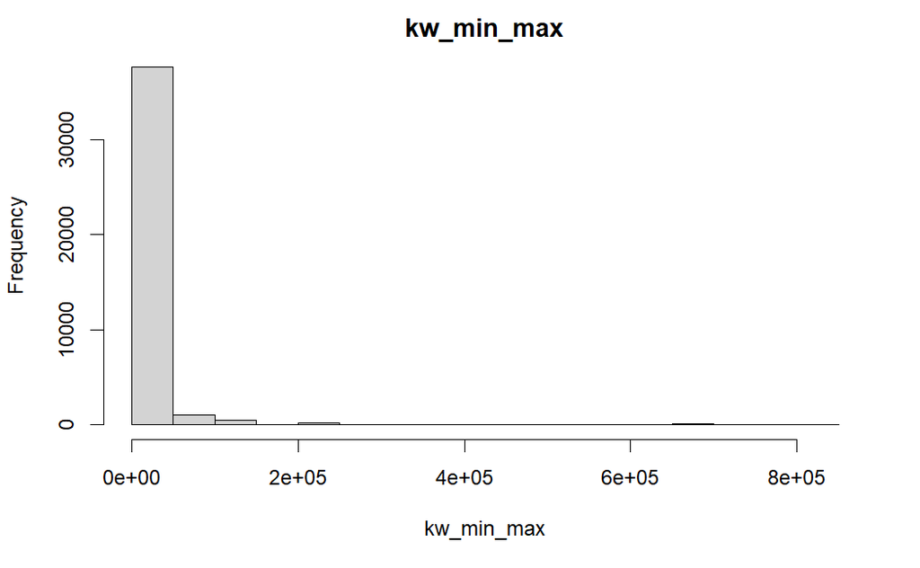

```r
library(caret)
degen.cols <- nearZeroVar(X)
for (i in degen.cols) {
  col.name <- names(X)[i]
  hist(X[, col.name], main = col.name, xlab = col.name)
}
```

kw_min_max has near-zero variance so let’s remove it.

```r
X <- X[, -degen.cols]
```

## Skew

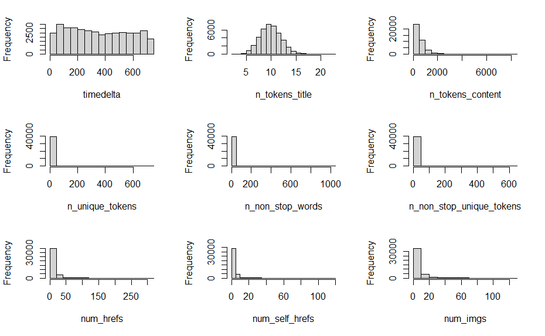

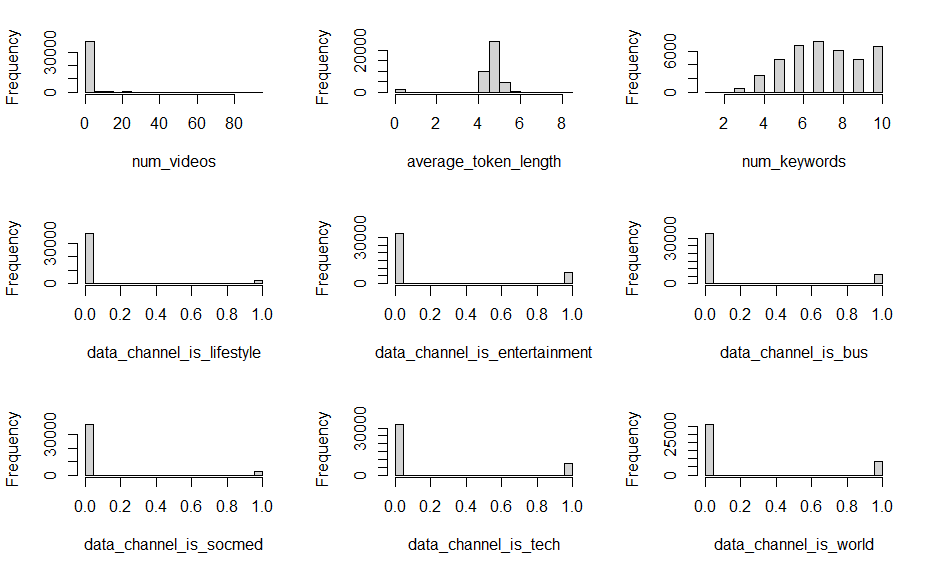

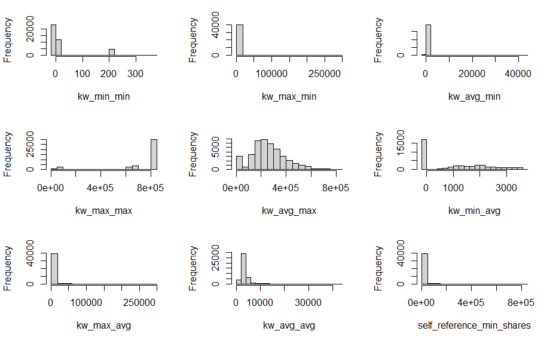

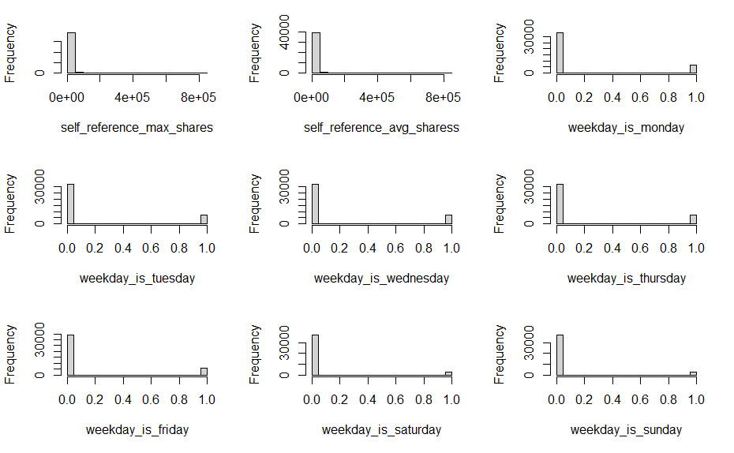

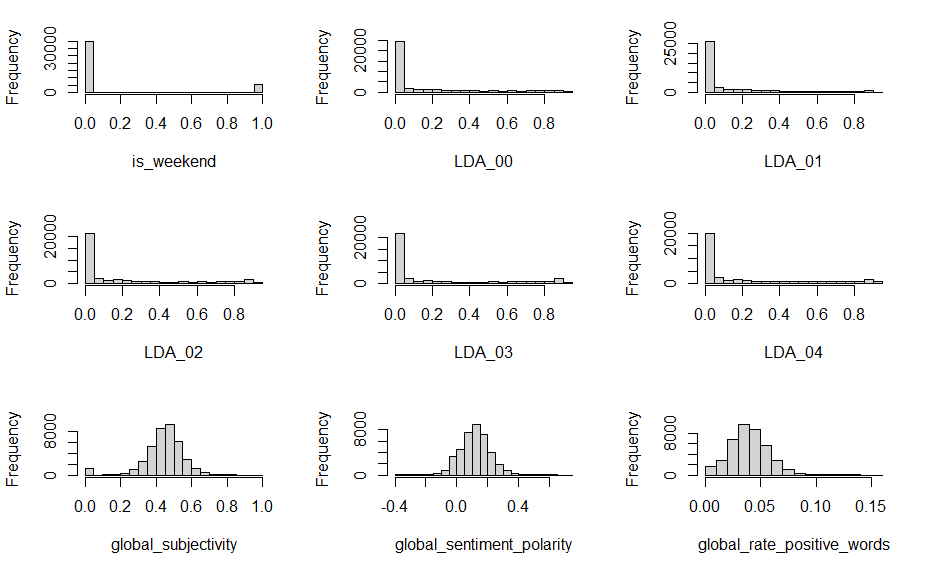

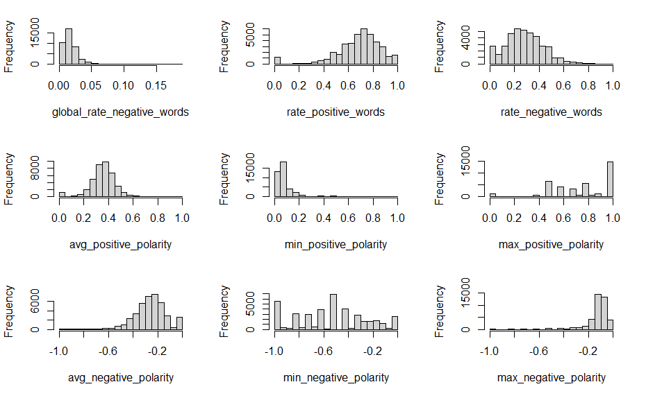

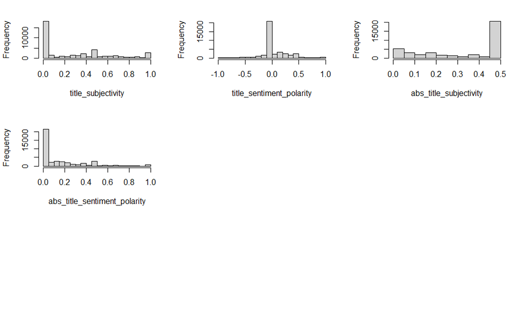

```r
par(mfrow = c(3, 3))
for (i in 1:ncol(X)) {
  hist(
    X[, i],
    main = NULL,
    xlab = colnames(X)[i]
  )
}
```

The predictors have widely varying ranges and many are quite skewed. We’ll need to center and scale them before modeling.

## Correlations

### Binary Predictor Correlations

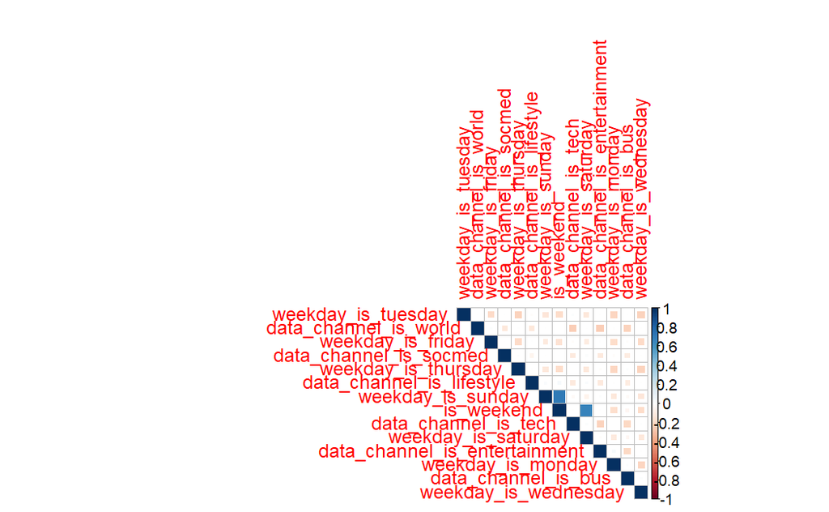

```r
library(corrplot)
X.bi <- Filter(function(x) all(x %in% c(0, 1)), X)
X.non.bi <- X[, !names(X) %in% names(X.bi)]
cor.bi <- cor(X.bi)
corrplot(
  cor.bi,
  method = "square",
  type = "upper",
  order = "hclust"
)
```

The only strong correlations among the binary predictors are between weekday_is_sunday and is_weekend and between weekday_is_saturday and is_weekend, which makes sense.

```r
high.cor.bi <- findCorrelation(cor.bi, cutoff = .7)
names(X.bi)[high.cor.bi]
```

```
[1] "is_weekend"
```

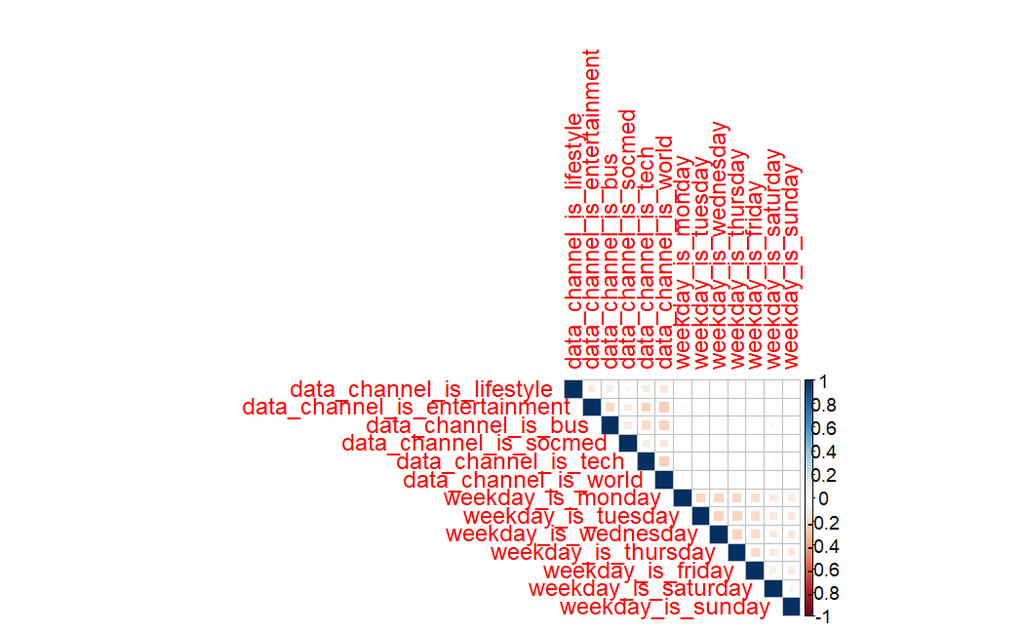

```r
X.bi <- X.bi[, -high.cor.bi] # remove is_weekend
cor.bi.filtered <- cor(X.bi)
corrplot(
  cor.bi.filtered,
  method = "square",
  type = "upper"
)
```

Remove weekday_is_sunday to avoid the dummy variable trap. Let’s also check the data channel binary predictors for the dummy variable trap.

```r
X.bi <- X.bi[, names(X.bi) != "weekday_is_sunday"]
channels <- c(
  "data_channel_is_world",
  "data_channel_is_socmed",
  "data_channel_is_tech",
  "data_channel_is_bus",
  "data_channel_is_entertainment",
  "data_channel_is_lifestyle"
)
summary(apply(X[, channels], 1, sum)) # check if they always sum to 1 for every sample
```

```
   Min. 1st Qu.  Median    Mean 3rd Qu.    Max.
 0.0000  1.0000  1.0000  0.8453  1.0000  1.0000
```

The channel predictors do not always sum to 1, so they do not fall into the dummy variable trap.

### Non-Binary Predictor Correlations

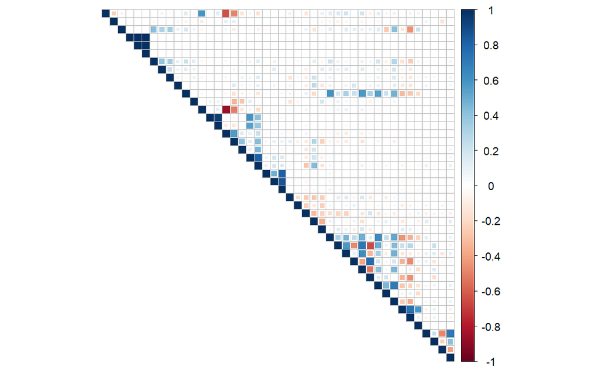

```r
cor.non.bi <- cor(X.non.bi)
corrplot(
  cor.non.bi,
  method = "square",
  type = "upper",
  tl.pos = "n"
)
```

We can see some strong positive and negative correlations between the non-binary predictors.

```r
high.cor.non.bi <- findCorrelation(cor.non.bi, cutoff = .7)
length(high.cor.non.bi)
```

```
[1] 12
```

```r
names(X.non.bi)[high.cor.non.bi]
```

```
 [1] "rate_positive_words"       "avg_positive_polarity"
 [3] "kw_avg_avg"                "min_negative_polarity"
 [5] "rate_negative_words"       "kw_max_max"
 [7] "title_subjectivity"        "self_reference_max_shares"
 [9] "kw_max_min"                "n_non_stop_words"
[11] "self_reference_min_shares" "n_unique_tokens"
```

12 variables contribute to high pairwise correlation between the non-binary predictors. Let’s remove them

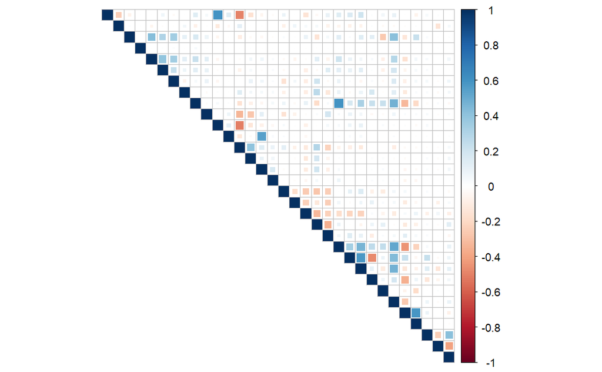

```r
X.non.bi <- X.non.bi[, -high.cor.non.bi]
cor.non.bi.filtered <- cor(X.non.bi)
corrplot(
  cor.non.bi.filtered,
  method = "square",
  type = "upper",
  tl.pos = "n"
)
```

Let’s update our master predictor matrix to only retain the non-problematic predictors.

```r
cols.to.keep <- c(names(X.bi), names(X.non.bi))
X <- X[, names(X) %in% cols.to.keep]
```

# Split the Data

```r
set.seed(100)
train.rows <- createDataPartition(y, p = .8, list = FALSE)
y.train <- y[train.rows]
y.test <- y[-train.rows]
X.train <- X[train.rows, ]
X.test <- X[-train.rows, ]
idx <- createFolds(y.train, returnTrain = TRUE)
ctrl <- trainControl(method = "cv", index = idx)
```

# Modeling

## Linear Models

### Elastic Net

```r
enetGrid <- expand.grid(lambda = c(0, 0.01, .1),
                        fraction = seq(0, 1, length = 10))
set.seed(100)
enet <- train(x = X.train, y = y.train,
                         method = "enet",
                         tuneGrid = enetGrid,
                         trControl = ctrl,
                         preProc = c("center", "scale"))
enet
```

```
Elasticnet

31716 samples
   44 predictor

Pre-processing: centered (44), scaled (44)
Resampling: Cross-Validated (10 fold)
Summary of sample sizes: 28545, 28543, 28544, 28545, 28545, 28543, ...
Resampling results across tuning parameters:

  lambda  fraction   RMSE       Rsquared    MAE
  0.00    0.0000000  0.9321901         NaN  0.7055694
  0.00    0.1111111  0.8864478  0.09719415  0.6583323
  0.00    0.2222222  0.8984610  0.09224848  0.6581408
  0.00    0.3333333  1.0141256  0.09176563  0.6601719
  0.00    0.4444444  1.0105262  0.09178231  0.6597225
  0.00    0.5555556  0.9917711  0.09181401  0.6591108
  0.00    0.6666667  0.9714230  0.09187086  0.6585251
  0.00    0.7777778  0.9437185  0.09203142  0.6578012
  0.00    0.8888889  0.9253482  0.09228926  0.6573308
  0.00    1.0000000  0.9255977  0.09228056  0.6573320
  0.01    0.0000000  0.9321901         NaN  0.7055694
  0.01    0.1111111  0.9124461  0.06195643  0.6876086
  0.01    0.2222222  0.9020839  0.07603802  0.6761242
  0.01    0.3333333  0.9930125  0.07909097  0.6712378
  0.01    0.4444444  1.0242694  0.08325657  0.6672900
  0.01    0.5555556  1.0084331  0.08667635  0.6639962
  0.01    0.6666667  0.9932545  0.08918634  0.6617399
  0.01    0.7777778  0.9742261  0.09087545  0.6599432
  0.01    0.8888889  0.9506518  0.09180482  0.6584963
  0.01    1.0000000  0.9352032  0.09208036  0.6576853
  0.10    0.0000000  0.9321901         NaN  0.7055694
  0.10    0.1111111  0.9144814  0.05737692  0.6895019
  0.10    0.2222222  0.9034129  0.07577590  0.6787493
  0.10    0.3333333  0.9301465  0.07640761  0.6725192
  0.10    0.4444444  1.0012548  0.08049357  0.6692252
  0.10    0.5555556  1.0204530  0.08394508  0.6662717
  0.10    0.6666667  1.0174417  0.08655568  0.6638276
  0.10    0.7777778  1.0120269  0.08835610  0.6620833
  0.10    0.8888889  1.0030191  0.08960134  0.6607376
  0.10    1.0000000  0.9915162  0.09028498  0.6597427

RMSE was used to select the optimal model using the smallest value.
The final values used for the model were fraction = 0.1111111 and lambda = 0.
```

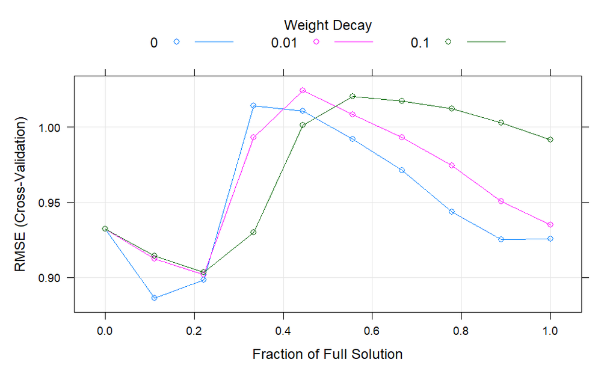

```r
plot(enet)
```

```r
library(Metrics)
pred.enet <- predict(enet, X.test)
resid.enet <- y.test - pred.enet
rmse(y.test, pred.enet)
```

```
[1] 0.8736786
```

```r
par(mfrow = c(2, 2))
hist(pred.enet)
plot(y.test, pred.enet)
```

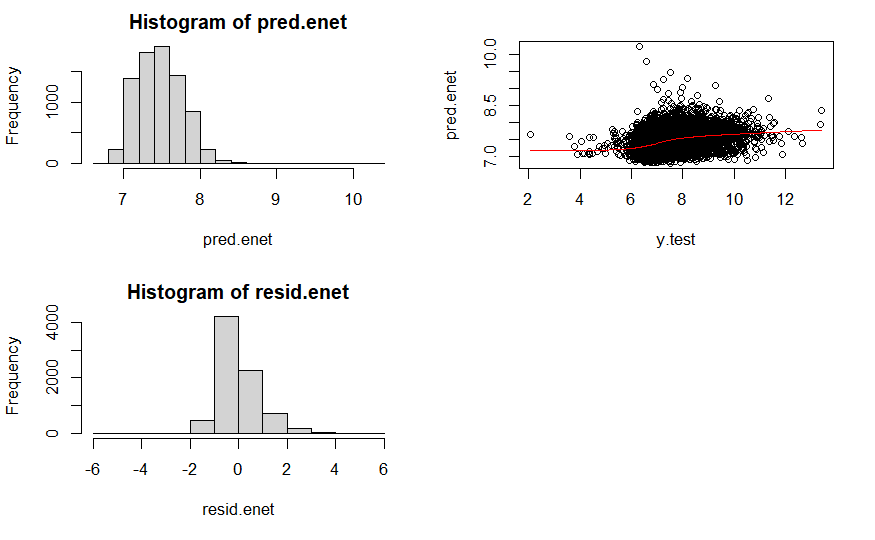

```r
lines(lowess(y.test, pred.enet), col = "red")
hist(resid.enet)
```

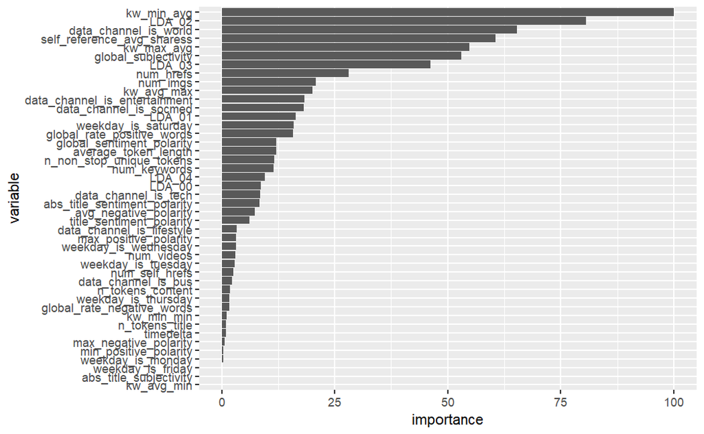

```r
library(tidyr)
library(dplyr)
plot.var.imp <- function(model) {
  imp <- varImp(model)$importance
  names(imp) <- "importance"
  df <- imp %>%
    tibble::rownames_to_column() %>%
    dplyr::rename("variable" = rowname) %>%
    dplyr::arrange(importance) %>%
    dplyr::mutate(variable = forcats::fct_inorder(variable))
  ggplot(df) +
    geom_col(aes(x = variable, y = importance)) +
    coord_flip()
}
plot.var.imp(enet)
```

### Principal Component Regression (PCR)

```r
set.seed(100)
pcr <- train(
  x = X.train,
  y = y.train,
  preProc = c("center", "scale"),
  method = "pcr",
  tuneGrid = expand.grid(ncomp = 1:30),
  trControl = ctrl
)
pcr
```

```
Principal Component Analysis

31716 samples
   44 predictor

Pre-processing: centered (44), scaled (44)
Resampling: Cross-Validated (10 fold)
Summary of sample sizes: 28545, 28543, 28544, 28545, 28545, 28543, ...
Resampling results across tuning parameters:

  ncomp  RMSE       Rsquared    MAE
   1     0.9564855  0.01178708  0.6999365
   2     0.9506298  0.01371925  0.7006422
   3     1.0055397  0.02027480  0.6970122
   4     1.0264125  0.03108140  0.6935467
```

[output cut: 29 more lines]

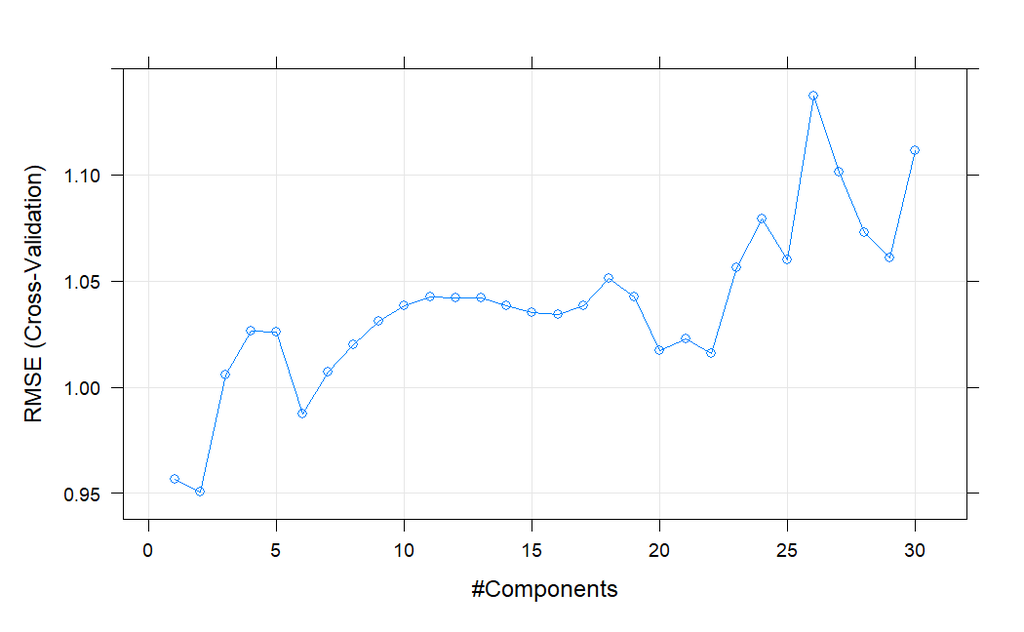

```r
plot(pcr)
```

```r
pred.pcr <- predict(pcr, X.test)
resid.pcr <- y.test - pred.pcr
rmse(y.test, pred.pcr)
```

```
[1] 0.9152851
```

```r
par(mfrow = c(2, 2))
hist(pred.pcr)
plot(y.test, pred.pcr)
```

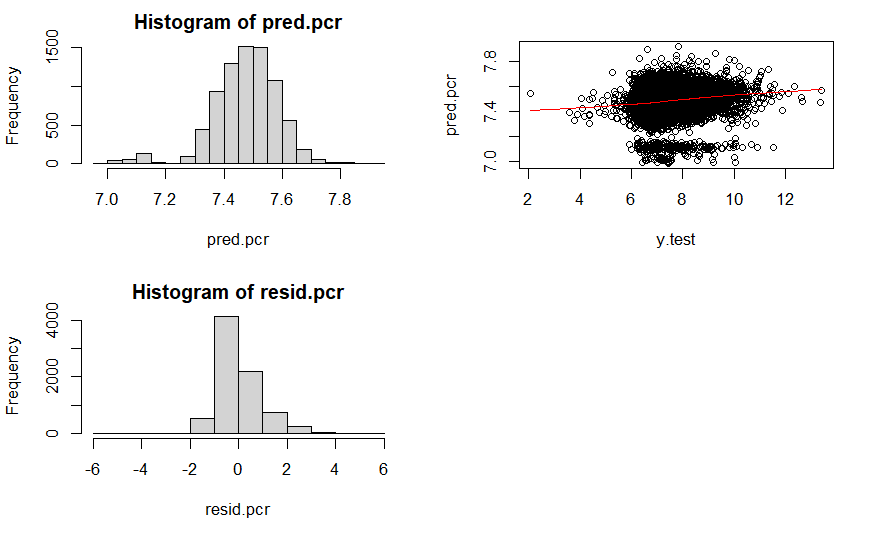

```r
lines(lowess(y.test, pred.pcr), col = "red")
hist(resid.pcr)
```

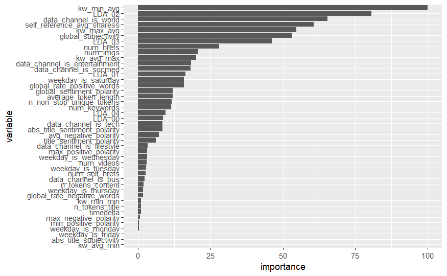

```r
plot.var.imp(pcr)
```

```r
set.seed(100)
pls <- train(
  x = X.train,
  y = y.train,
  preProc = c("center", "scale"),
  method = "pls",
  tuneGrid = expand.grid(ncomp = 1:30),
  trControl = ctrl
)
pls
```

```
Partial Least Squares

31716 samples
   44 predictor

Pre-processing: centered (44), scaled (44)
Resampling: Cross-Validated (10 fold)
Summary of sample sizes: 28545, 28543, 28544, 28545, 28545, 28543, ...
Resampling results across tuning parameters:

  ncomp  RMSE       Rsquared    MAE
   1     1.0081791  0.07008790  0.6725356
   2     1.1050275  0.08177957  0.6672321
   3     1.0287718  0.08596654  0.6621882
   4     1.0406781  0.08813904  0.6619958
```

[output cut: 29 more lines]

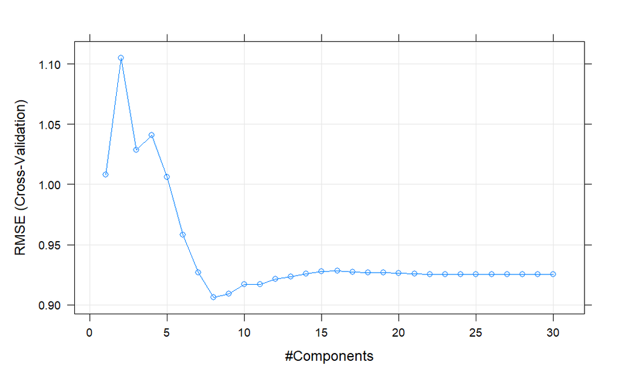

```r
plot(pls)
```

```r
pred.pls <- predict(pls, X.test)
resid.pls <- y.test - pred.pls
rmse(y.test, pred.pls)
```

```
[1] 0.8735161
```

```r
par(mfrow = c(2, 2))
hist(pred.pls)
plot(y.test, pred.pls)
```

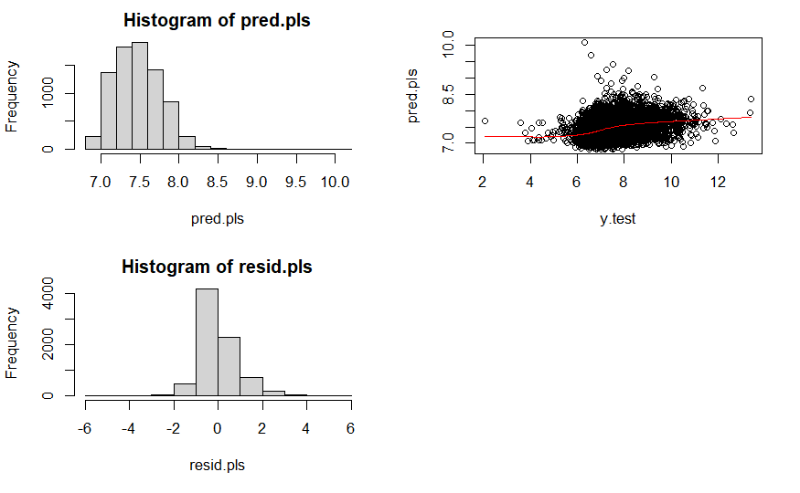

```r
lines(lowess(y.test, pred.pls), col = "red")
hist(resid.pls)
```

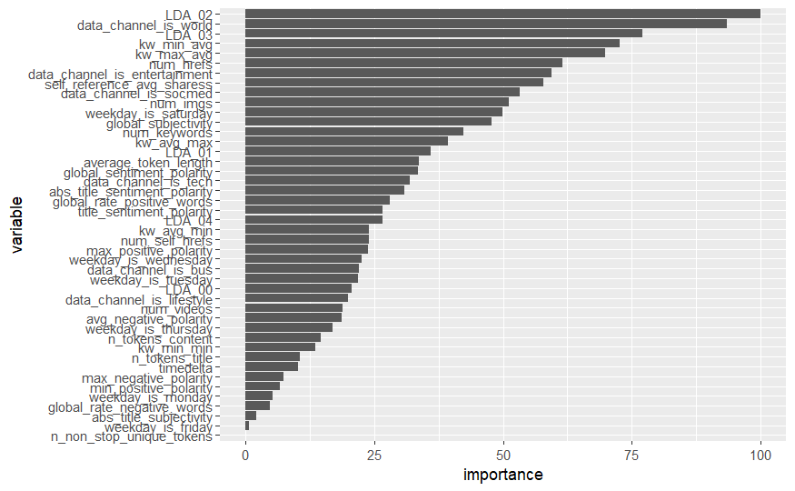

```r
plot.var.imp(pls)
```

## Non-Linear Models

### K-Nearest Neighbors (k-NN)

```r
set.seed(100)
knn <- train(
  x = X.train,
  y = y.train,
  preProc = c("center", "scale"),
  method = "knn",
  tuneGrid = expand.grid(k = 1:10),
  trControl = ctrl
)
knn
```

```
k-Nearest Neighbors

31716 samples
   44 predictor

Pre-processing: centered (44), scaled (44)
Resampling: Cross-Validated (10 fold)
Summary of sample sizes: 28545, 28543, 28544, 28545, 28545, 28543, ...
Resampling results across tuning parameters:

  k   RMSE       Rsquared    MAE
   1  1.2072226  0.02173822  0.8848739
   2  1.0509486  0.03416209  0.7788457
   3  0.9922019  0.04473664  0.7359284
   4  0.9623583  0.05301447  0.7129060
   5  0.9447195  0.05963674  0.6985403
   6  0.9311917  0.06663565  0.6866949
   7  0.9219106  0.07177303  0.6787405
   8  0.9153567  0.07573898  0.6731041
   9  0.9095756  0.08010333  0.6678407
  10  0.9062993  0.08204549  0.6646600

RMSE was used to select the optimal model using the smallest value.
The final value used for the model was k = 10.
```

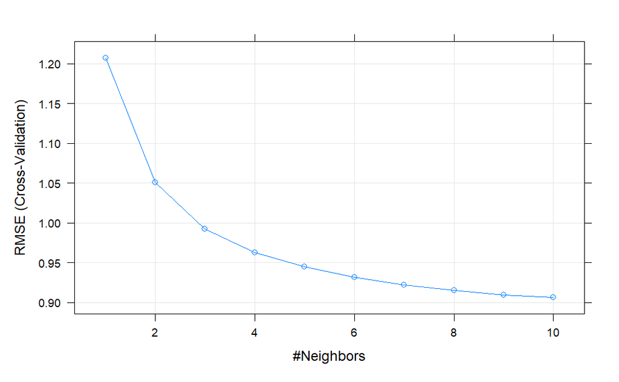

```r
plot(knn)
```

```r
pred.knn <- predict(knn, X.test)
resid.knn <- y.test - pred.knn
rmse(y.test, pred.knn)
```

```
[1] 0.9015301
```

```r
par(mfrow = c(2, 2))
hist(pred.knn)
plot(y.test, pred.knn)
```

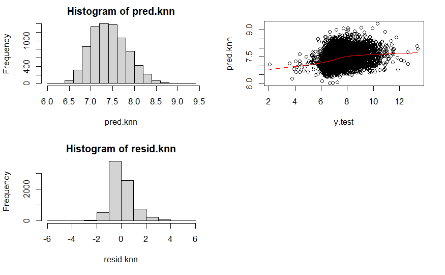

```r
lines(lowess(y.test, pred.knn), col = "red")
hist(resid.knn)
```

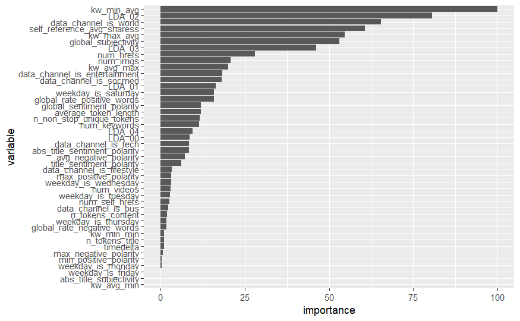

```r
plot.var.imp(knn)
```

### Classification and Regression Tree (CART)

```r
set.seed(100)
cart <- train(
  x = X.train,
  y = y.train,
  preProc = c("center", "scale"),
  method = "rpart",
  tuneGrid = expand.grid(cp = seq(0.001, 0.1, 0.01))
)
cart
```

```
CART

31716 samples
   44 predictor

Pre-processing: centered (44), scaled (44)
Resampling: Bootstrapped (25 reps)
Summary of sample sizes: 31716, 31716, 31716, 31716, 31716, 31716, ...
Resampling results across tuning parameters:

  cp     RMSE       Rsquared    MAE
  0.001  0.8924639  0.08998393  0.6621639
  0.011  0.9019196  0.05988036  0.6800254
  0.021  0.9081914  0.04668786  0.6855366
  0.031  0.9107644  0.04119749  0.6878669
  0.041  0.9115580  0.04114349  0.6885583
  0.051  0.9300558         NaN  0.7044480
  0.061  0.9300558         NaN  0.7044480
  0.071  0.9300558         NaN  0.7044480
  0.081  0.9300558         NaN  0.7044480
  0.091  0.9300558         NaN  0.7044480

RMSE was used to select the optimal model using the smallest value.
The final value used for the model was cp = 0.001.
```

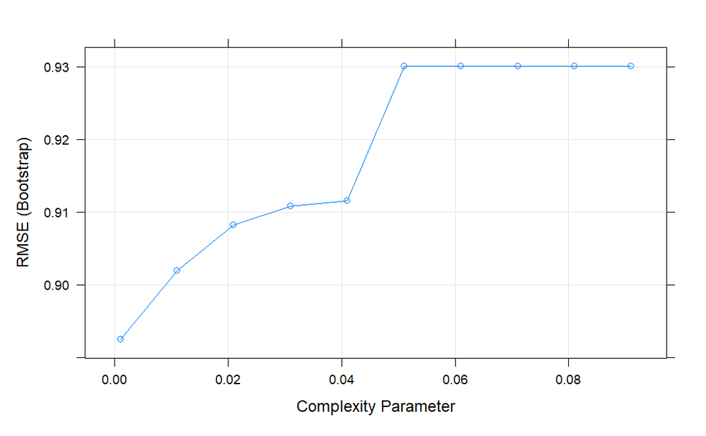

```r
plot(cart)
```

```r
pred.cart <- predict(cart, X.test)
resid.cart <- y.test - pred.cart
rmse(y.test, pred.cart)
```

```
[1] 0.8773104
```

```r
par(mfrow = c(2, 2))
hist(pred.cart)
plot(y.test, pred.cart)
```

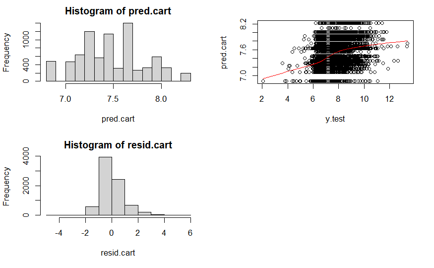

```r
lines(lowess(y.test, pred.cart), col = "red")
hist(resid.cart)
```

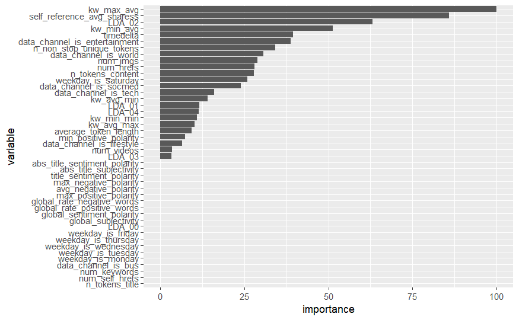

```r
plot.var.imp(cart)
```

### Stochastic Gradient Boosting

```r
set.seed(100)
gbm.grid <- expand.grid(n.trees = 100, interaction.depth = 1:5, shrinkage = c(0.01, 0.1), n.minobsinnode = 10)
gbm <- train(
  x = X.train,
  y = y.train,
  trControl = ctrl,
  preProc = c("center", "scale"),
  method = "gbm",
  tuneGrid = gbm.grid
)
gbm
```

```
Stochastic Gradient Boosting

31716 samples
   44 predictor

Pre-processing: centered (44), scaled (44)
Resampling: Cross-Validated (10 fold)
Summary of sample sizes: 28545, 28543, 28544, 28545, 28545, 28543, ...
Resampling results across tuning parameters:

  shrinkage  interaction.depth  RMSE       Rsquared    MAE
  0.01       1                  0.9083963  0.08445183  0.6855248
  0.01       2                  0.9012932  0.09478318  0.6790713
  0.01       3                  0.8966554  0.10567896  0.6742977
  0.01       4                  0.8936561  0.11116160  0.6713627
  0.01       5                  0.8914927  0.11522411  0.6690840
  0.10       1                  0.8726627  0.12823473  0.6497059
  0.10       2                  0.8651327  0.14071612  0.6416147
  0.10       3                  0.8608702  0.14864414  0.6381675
  0.10       4                  0.8586408  0.15283182  0.6358339
  0.10       5                  0.8573851  0.15501048  0.6346975

Tuning parameter 'n.trees' was held constant at a value of 100
Tuning parameter 'n.minobsinnode' was held constant at a value of 10
RMSE was used to select the optimal model using the smallest value.
The final values used for the model were n.trees = 100, interaction.depth = 5, shrinkage = 0.1 and n.minobsinnode = 10.
```

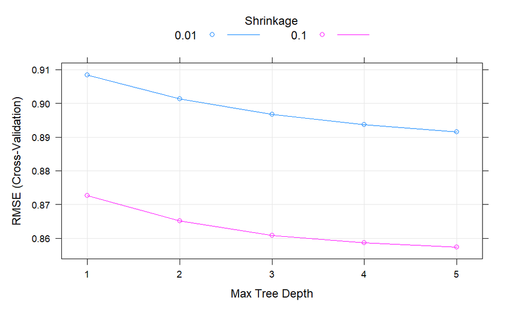

```r
plot(gbm)
```

```r
pred.gbm <- predict(gbm, X.test)
resid.gbm <- y.test - pred.gbm
rmse(y.test, pred.gbm)
```

```
[1] 0.8479553
```

```r
par(mfrow = c(2, 2))
hist(pred.gbm)
plot(y.test, pred.gbm)
```

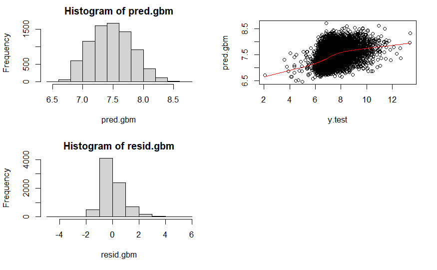

```r
lines(lowess(y.test, pred.gbm), col = "red")
hist(resid.gbm)
```

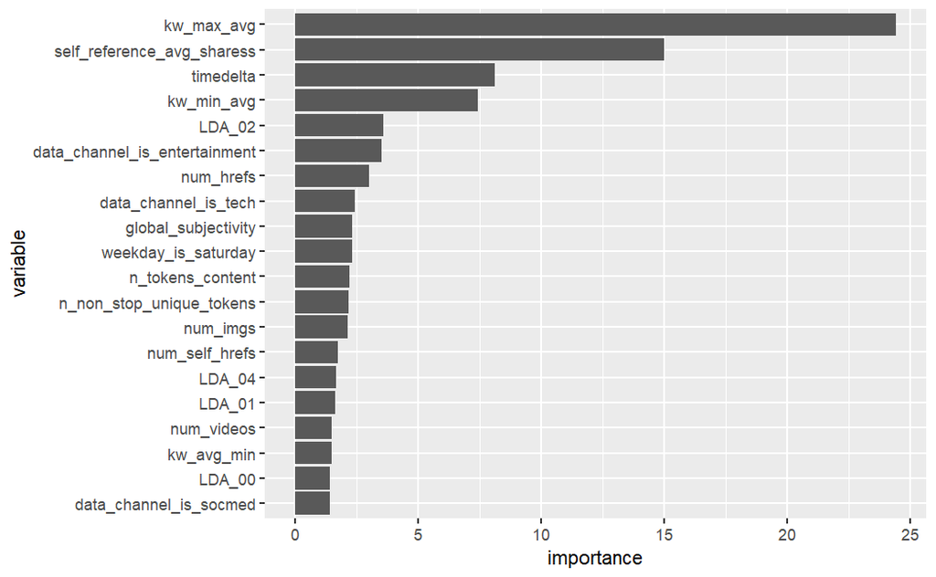

```r
library(gbm)
gbm.imp <- summary.gbm(gbm$finalModel, plotit = FALSE)[1:20, ]
names(gbm.imp) <- c("variable", "importance")
gbm.imp.df <- gbm.imp %>%
  dplyr::arrange(importance) %>%
  dplyr::mutate(variable = forcats::fct_inorder(variable))
ggplot(gbm.imp.df) +
  geom_col(aes(x = variable, y = importance)) +
  coord_flip()
```

# Compare Model Performance

```r
# function to calculate R-squared
r.squared <- function(actual, predicted) {
  actual.mean <- mean(actual)
  RSS <- sum((actual - predicted)^2)
  TSS <- sum((actual - actual.mean)^2)
  R2 <- 1 - (RSS/TSS)
  return(R2)
}
```

```r
# create dataframe to contain all model results
models <- c("enet", "pcr", "pls", "knn", "cart", "gbm")
results <- data.frame(row.names = models)
results$RMSE.cv <- NA
results$RMSE.cv.sd <- NA
results$RMSE.test <- NA
results$Rsquared.cv <- NA
results$Rsquared.cv.sd <- NA
results$Rsquared.test <- NA

# add enet results
results.enet <- enet$results %>%
  filter(lambda == enet$bestTune$lambda & fraction == enet$bestTune$fraction) %>%
  select(RMSE, RMSESD, Rsquared, RsquaredSD)

results["enet", "RMSE.cv"] <- results.enet$RMSE
results["enet", "RMSE.cv.sd"] <- results.enet$RMSESD
results["enet", "RMSE.test"] <- rmse(y.test, pred.enet)
results["enet", "Rsquared.cv"] <- results.enet$Rsquared
results["enet", "Rsquared.cv.sd"] <- results.enet$RsquaredSD
results["enet", "Rsquared.test"] <- r.squared(y.test, pred.enet)

# add PCR results
results.pcr <- pcr$results %>%
  filter(ncomp == pcr$bestTune$ncomp) %>%
  select(RMSE, RMSESD, Rsquared, RsquaredSD)

results["pcr", "RMSE.cv"] <- results.pcr$RMSE
results["pcr", "RMSE.cv.sd"] <- results.pcr$RMSESD
results["pcr", "RMSE.test"] <- rmse(y.test, pred.pcr)
results["pcr", "Rsquared.cv"] <- results.pcr$Rsquared
results["pcr", "Rsquared.cv.sd"] <- results.pcr$RsquaredSD
results["pcr", "Rsquared.test"] <- r.squared(y.test, pred.pcr)

# add PLS results
results.pls <- pls$results %>%
  filter(ncomp == pls$bestTune$ncomp) %>%
  select(RMSE, RMSESD, Rsquared, RsquaredSD)

results["pls", "RMSE.cv"] <- results.pls$RMSE
results["pls", "RMSE.cv.sd"] <- results.pls$RMSESD
results["pls", "RMSE.test"] <- rmse(y.test, pred.pls)
results["pls", "Rsquared.cv"] <- results.pls$Rsquared
results["pls", "Rsquared.cv.sd"] <- results.pls$RsquaredSD
results["pls", "Rsquared.test"] <- r.squared(y.test, pred.pls)

# add KNN results
results.knn <- knn$results %>%
  filter(k == knn$bestTune$k) %>%
  select(RMSE, RMSESD, Rsquared, RsquaredSD)

results["knn", "RMSE.cv"] <- results.knn$RMSE
results["knn", "RMSE.cv.sd"] <- results.knn$RMSESD
results["knn", "RMSE.test"] <- rmse(y.test, pred.knn)
results["knn", "Rsquared.cv"] <- results.knn$Rsquared
results["knn", "Rsquared.cv.sd"] <- results.knn$RsquaredSD
results["knn", "Rsquared.test"] <- r.squared(y.test, pred.knn)

# add CART results
results.cart <- cart$results %>%
  filter(cp == cart$bestTune$cp) %>%
  select(RMSE, RMSESD, Rsquared, RsquaredSD)

results["cart", "RMSE.cv"] <- results.cart$RMSE
results["cart", "RMSE.cv.sd"] <- results.cart$RMSESD
results["cart", "RMSE.test"] <- rmse(y.test, pred.cart)
results["cart", "Rsquared.cv"] <- results.cart$Rsquared
results["cart", "Rsquared.cv.sd"] <- results.cart$RsquaredSD
results["cart", "Rsquared.test"] <- r.squared(y.test, pred.cart)

# add GBM results
results.gbm <- gbm$results %>%
  filter(shrinkage == gbm$bestTune$shrinkage & interaction.depth == gbm$bestTune$interaction.depth) %>%
  select(RMSE, RMSESD, Rsquared, RsquaredSD)

results["gbm", "RMSE.cv"] <- results.gbm$RMSE
results["gbm", "RMSE.cv.sd"] <- results.gbm$RMSESD
results["gbm", "RMSE.test"] <- rmse(y.test, pred.gbm)
results["gbm", "Rsquared.cv"] <- results.gbm$Rsquared
results["gbm", "Rsquared.cv.sd"] <- results.gbm$RsquaredSD
results["gbm", "Rsquared.test"] <- r.squared(y.test, pred.gbm)

results
```

|  | RMSE.cv | RMSE.cv.sd | RMSE.test | Rsquared.cv | Rsquared.cv.sd | Rsquared.test |
| --- | --- | --- | --- | --- | --- | --- |
| enet | 0.8864478 | 0.021979139 | 0.8736786 | 0.09719415 | 0.016801650 | 0.10398836 |
| pcr | 0.9506298 | 0.084007318 | 0.9152851 | 0.01371925 | 0.006115983 | 0.01661621 |
| pls | 0.9061434 | 0.074589273 | 0.8735161 | 0.09218942 | 0.028958196 | 0.10432158 |
| knn | 0.9062993 | 0.019273590 | 0.9015301 | 0.08204549 | 0.009945894 | 0.04595076 |
| cart | 0.8924639 | 0.007097887 | 0.8773104 | 0.08998393 | 0.006609173 | 0.09652342 |
| gbm | 0.8573851 | 0.017649409 | 0.8479553 | 0.15501048 | 0.010350722 | 0.15597315 |